# Project 1: Titanic Analysis

In its day, the Titanic was known as the ‘unsinkable ship’. Unfortunately, it hit an iceberg and a lot of people died. This project is an attempt to visualize data about the passengers of the Titanic.

Before generating plots, we run the source file to make sure the necessary packages are in place.

```r
source("../require.R")
```

```
##
##
##
##
##
##
## Registering fonts with R
```

### Summary and Subset:

```r
source("../01 Data/Summary.R", echo = TRUE)
```

```
##
## > sexNotNullDf <- data.frame(fromJSON(getURL(URLencode("129.152.144.84:5001/rest/native/?query=\"select * from titanic where sex is not null\""),
## +   .... [TRUNCATED]
##
## > summary(sexNotNullDf)
##   PASSENGERID       SURVIVED          PCLASS
##  Min.   :  1.0   Min.   :0.0000   Min.   :1.000
##  1st Qu.:223.5   1st Qu.:0.0000   1st Qu.:2.000
##  Median :446.0   Median :0.0000   Median :3.000
##  Mean   :446.0   Mean   :0.3838   Mean   :2.309
##  3rd Qu.:668.5   3rd Qu.:1.0000   3rd Qu.:3.000
##  Max.   :891.0   Max.   :1.0000   Max.   :3.000
##
##                                     NAME         SEX           AGE
##  Abbing, Mr. Anthony                  :  1   female:314   null   :177
##  Abbott, Mr. Rossmore Edward          :  1   male  :577   24     : 30
##  Abbott, Mrs. Stanton (Rosa Hunt)     :  1                22     : 27
##  Abelson, Mr. Samuel                  :  1                18     : 26
##  Abelson, Mrs. Samuel (Hannah Wizosky):  1                19     : 25
##  Adahl, Mr. Mauritz Nils Martin       :  1                28     : 25
##  (Other)                              :885                (Other):581
##      SIBSP           PARCH             TICKET         FARE
##  Min.   :0.000   Min.   :0.0000   1601    :  7   Min.   :  0.00
##  1st Qu.:0.000   1st Qu.:0.0000   347082  :  7   1st Qu.:  7.91
##  Median :0.000   Median :0.0000   CA. 2343:  7   Median : 14.45
##  Mean   :0.523   Mean   :0.3816   3101295 :  6   Mean   : 32.20
##  3rd Qu.:1.000   3rd Qu.:0.0000   347088  :  6   3rd Qu.: 31.00
##  Max.   :8.000   Max.   :6.0000   CA 2144 :  6   Max.   :512.33
##                                   (Other) :852
##          CABIN     EMBARKED
##  null       :687   C   :168
##  B96 B98    :  4   null:  2
##  C23 C25 C27:  4   Q   : 77
##  G6         :  4   S   :644
##  C22 C26    :  3
##  D          :  3
##  (Other)    :186
##
## > head(sexNotNullDf)
##   PASSENGERID SURVIVED PCLASS                                  NAME    SEX
## 1         311        1      1        Hays, Miss. Margaret Bechstein female
## 2         312        1      1            Ryerson, Miss. Emily Borie female
## 3         313        0      2 Lahtinen, Mrs. William (Anna Sylfven) female
## 4         314        0      3                Hendekovic, Mr. Ignjac   male
## 5         315        0      2                    Hart, Mr. Benjamin   male
## 6         316        1      3       Nilsson, Miss. Helmina Josefina female
##   AGE SIBSP PARCH       TICKET     FARE           CABIN EMBARKED
## 1  24     0     0        11767  83.1583             C54        C
## 2  18     2     2     PC 17608 262.3750 B57 B59 B63 B66        C
## 3  26     1     1       250651  26.0000            null        S
## 4  28     0     0       349243   7.8958            null        S
## 5  43     1     1 F.C.C. 13529  26.2500            null        S
## 6  26     0     0       347470   7.8542            null        S
```

### Plot #1:

This visualization uses a fairly general SQL statement. Everything from the database is pulled into the data frame. The visualization produced shows who was on the Titanic, by fare and sex.

```
##
## > require("jsonlite")
##
## > require("RCurl")
##
## > nullDf <- data.frame(fromJSON(getURL(URLencode("129.152.144.84:5001/rest/native/?query=\"select * from titanic\""),
## +     httpheader = c(DB = "jdbc ..." ... [TRUNCATED]
##
## > summary(nullDf)
##                                       PASSENGERID  SURVIVED    PCLASS
##  </pre></body></html>Xtext/csvUUTF-8(?N`vPJS:  1   0   :549   1   :216
##  1                                          :  1   1   :342   2   :184
##  10                                         :  1   null:  2   3   :491
##  100                                        :  1              null:  2
##  101                                        :  1
##  102                                        :  1
##  (Other)                                    :887
##                                     NAME         SEX           AGE
##  null                                 :  2   female:314   null   :179
##  Abbing, Mr. Anthony                  :  1   male  :577   24     : 30
##  Abbott, Mr. Rossmore Edward          :  1   null  :  2   22     : 27
##  Abbott, Mrs. Stanton (Rosa Hunt)     :  1                18     : 26
##  Abelson, Mr. Samuel                  :  1                19     : 25
##  Abelson, Mrs. Samuel (Hannah Wizosky):  1                28     : 25
##  (Other)                              :886                (Other):581
##      SIBSP         PARCH          TICKET                  FARE
##  0      :608   0      :678   1601    :  7   8.05000019073486: 43
##  1      :209   1      :118   347082  :  7   13              : 42
##  2      : 28   2      : 80   CA. 2343:  7   7.89580011367798: 38
##  4      : 18   3      :  5   3101295 :  6   7.75            : 34
##  3      : 16   5      :  5   347088  :  6   26              : 31
##  8      :  7   4      :  4   CA 2144 :  6   10.5            : 24
##  (Other):  7   (Other):  3   (Other) :854   (Other)         :681
##          CABIN     EMBARKED
##  null       :689   C   :168
##  B96 B98    :  4   null:  4
##  C23 C25 C27:  4   Q   : 77
##  G6         :  4   S   :644
##  C22 C26    :  3
##  D          :  3
```

[output cut: 8 more lines]

```
## 5         315        0      2                    Hart, Mr. Benjamin   male
## 6         316        1      3       Nilsson, Miss. Helmina Josefina female
##   AGE SIBSP PARCH       TICKET             FARE           CABIN EMBARKED
## 1  24     0     0        11767 83.1583023071289             C54        C
## 2  18     2     2     PC 17608          262.375 B57 B59 B63 B66        C
## 3  26     1     1       250651               26            null        S
## 4  28     0     0       349243 7.89580011367798            null        S
## 5  43     1     1 F.C.C. 13529            26.25            null        S
## 6  26     0     0       347470 7.85419988632202            null        S
##
## > require(extrafont)
##
## > ggplot() + coord_cartesian() + scale_x_continuous() +
## +     scale_y_continuous() + labs(title = "Titanic") + labs(x = "Age",
## +     y = paste("Fare ..." ... [TRUNCATED]
```

```
## Warning: NAs introduced by coercion
```

```
## Warning: Removed 179 rows containing missing values (geom_point).
```

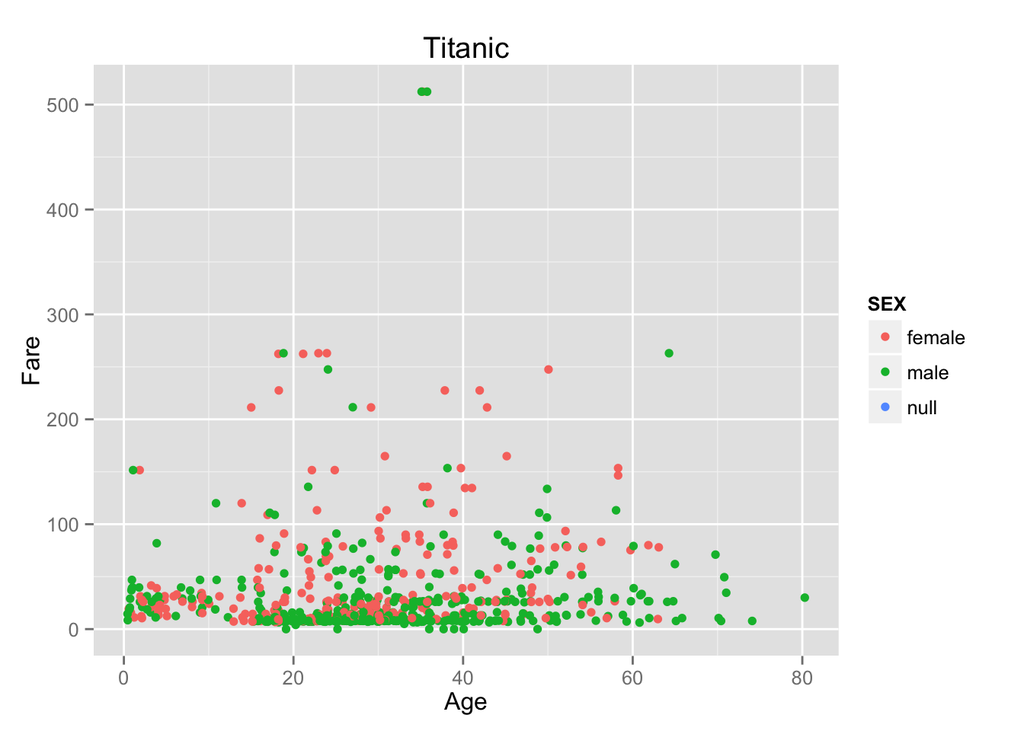

```r
source("../02 Visualizations/plot1.R", echo = TRUE)
```

**Code Analysis**

In this code, there is “junk data” in the summary present in the null data points. Warnings are produced because of NULL data rows. Both fare and age are identified as continuous variables.

**Plot Analysis**

In this plot, we see that most people on the ship who paid over $200 for their ticket were female. Additionally, we see that the majority of the passengers on the ship paid less than $100 for their ticket.

### Plot #2:

```
##
## > sexNotNullDf <- data.frame(fromJSON(getURL(URLencode("129.152.144.84:5001/rest/native/?query=\"select * from titanic where sex is not null\""),
## +   .... [TRUNCATED]
##
## > summary(sexNotNullDf)
##   PASSENGERID       SURVIVED          PCLASS
##  Min.   :  1.0   Min.   :0.0000   Min.   :1.000
##  1st Qu.:223.5   1st Qu.:0.0000   1st Qu.:2.000
##  Median :446.0   Median :0.0000   Median :3.000
##  Mean   :446.0   Mean   :0.3838   Mean   :2.309
##  3rd Qu.:668.5   3rd Qu.:1.0000   3rd Qu.:3.000
##  Max.   :891.0   Max.   :1.0000   Max.   :3.000
##
##                                     NAME         SEX           AGE
##  Abbing, Mr. Anthony                  :  1   female:314   null   :177
##  Abbott, Mr. Rossmore Edward          :  1   male  :577   24     : 30
##  Abbott, Mrs. Stanton (Rosa Hunt)     :  1                22     : 27
##  Abelson, Mr. Samuel                  :  1                18     : 26
##  Abelson, Mrs. Samuel (Hannah Wizosky):  1                19     : 25
##  Adahl, Mr. Mauritz Nils Martin       :  1                28     : 25
##  (Other)                              :885                (Other):581
##      SIBSP           PARCH             TICKET         FARE
##  Min.   :0.000   Min.   :0.0000   1601    :  7   Min.   :  0.00
##  1st Qu.:0.000   1st Qu.:0.0000   347082  :  7   1st Qu.:  7.91
##  Median :0.000   Median :0.0000   CA. 2343:  7   Median : 14.45
##  Mean   :0.523   Mean   :0.3816   3101295 :  6   Mean   : 32.20
##  3rd Qu.:1.000   3rd Qu.:0.0000   347088  :  6   3rd Qu.: 31.00
##  Max.   :8.000   Max.   :6.0000   CA 2144 :  6   Max.   :512.33
##                                   (Other) :852
##          CABIN     EMBARKED
##  null       :687   C   :168
##  B96 B98    :  4   null:  2
##  C23 C25 C27:  4   Q   : 77
##  G6         :  4   S   :644
##  C22 C26    :  3
##  D          :  3
##  (Other)    :186
##
## > head(sexNotNullDf)
##   PASSENGERID SURVIVED PCLASS                                  NAME    SEX
## 1         311        1      1        Hays, Miss. Margaret Bechstein female
## 2         312        1      1            Ryerson, Miss. Emily Borie female
## 3         313        0      2 Lahtinen, Mrs. William (Anna Sylfven) female
## 4         314        0      3                Hendekovic, Mr. Ignjac   male
## 5         315        0      2                    Hart, Mr. Benjamin   male
## 6         316        1      3       Nilsson, Miss. Helmina Josefina female
##   AGE SIBSP PARCH       TICKET     FARE           CABIN EMBARKED
## 1  24     0     0        11767  83.1583             C54        C
## 2  18     2     2     PC 17608 262.3750 B57 B59 B63 B66        C
## 3  26     1     1       250651  26.0000            null        S
## 4  28     0     0       349243   7.8958            null        S
## 5  43     1     1 F.C.C. 13529  26.2500            null        S
## 6  26     0     0       347470   7.8542            null        S
##
## > ggplot() + coord_cartesian() + scale_x_continuous() +
## +     scale_y_continuous() + labs(title = "Titanic") + labs(x = "Age",
## +     y = paste("Fare ..." ... [TRUNCATED]
```

```
## Warning: NAs introduced by coercion
```

```
## Warning: Removed 177 rows containing missing values (geom_point).
```

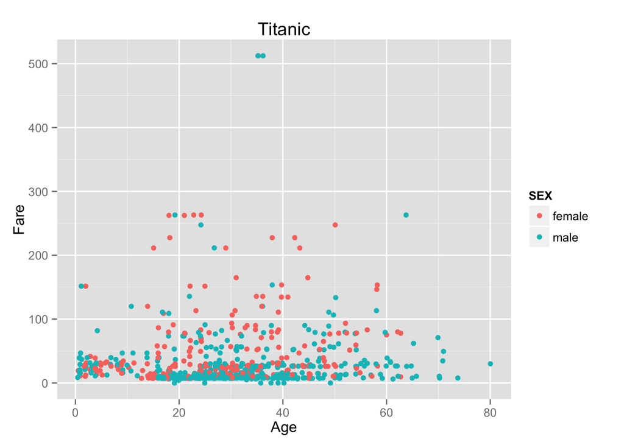

```r
source("../02 Visualizations/plot2.R", echo = TRUE)
```

**Code Analysis**

The difference between this plot and plot #1 is that we do not see junk “NULL” data.

**Plot Analysis**

In this plot, the legend is clearer and the unneccessary “NULL” marker is not present in the plot. We see, as in the first plot, that the majority of the passengers paid less than $100 for their Titanic tickets.

### Plot #3:

This visualization uses the same dataframe as plot #2. The plot visualizes survival by sex.

```
##
## > sexNotNullDf <- data.frame(fromJSON(getURL(URLencode("129.152.144.84:5001/rest/native/?query=\"select * from titanic where sex is not null\""),
## +   .... [TRUNCATED]
##
## > summary(sexNotNullDf)
##   PASSENGERID       SURVIVED          PCLASS
##  Min.   :  1.0   Min.   :0.0000   Min.   :1.000
##  1st Qu.:223.5   1st Qu.:0.0000   1st Qu.:2.000
##  Median :446.0   Median :0.0000   Median :3.000
##  Mean   :446.0   Mean   :0.3838   Mean   :2.309
##  3rd Qu.:668.5   3rd Qu.:1.0000   3rd Qu.:3.000
##  Max.   :891.0   Max.   :1.0000   Max.   :3.000
##
##                                     NAME         SEX           AGE
##  Abbing, Mr. Anthony                  :  1   female:314   null   :177
##  Abbott, Mr. Rossmore Edward          :  1   male  :577   24     : 30
##  Abbott, Mrs. Stanton (Rosa Hunt)     :  1                22     : 27
##  Abelson, Mr. Samuel                  :  1                18     : 26
##  Abelson, Mrs. Samuel (Hannah Wizosky):  1                19     : 25
##  Adahl, Mr. Mauritz Nils Martin       :  1                28     : 25
##  (Other)                              :885                (Other):581
##      SIBSP           PARCH             TICKET         FARE
##  Min.   :0.000   Min.   :0.0000   1601    :  7   Min.   :  0.00
##  1st Qu.:0.000   1st Qu.:0.0000   347082  :  7   1st Qu.:  7.91
##  Median :0.000   Median :0.0000   CA. 2343:  7   Median : 14.45
##  Mean   :0.523   Mean   :0.3816   3101295 :  6   Mean   : 32.20
##  3rd Qu.:1.000   3rd Qu.:0.0000   347088  :  6   3rd Qu.: 31.00
##  Max.   :8.000   Max.   :6.0000   CA 2144 :  6   Max.   :512.33
##                                   (Other) :852
##          CABIN     EMBARKED
##  null       :687   C   :168
##  B96 B98    :  4   null:  2
##  C23 C25 C27:  4   Q   : 77
##  G6         :  4   S   :644
##  C22 C26    :  3
##  D          :  3
##  (Other)    :186
##
## > head(sexNotNullDf)
##   PASSENGERID SURVIVED PCLASS                                  NAME    SEX
## 1         311        1      1        Hays, Miss. Margaret Bechstein female
## 2         312        1      1            Ryerson, Miss. Emily Borie female
## 3         313        0      2 Lahtinen, Mrs. William (Anna Sylfven) female
## 4         314        0      3                Hendekovic, Mr. Ignjac   male
## 5         315        0      2                    Hart, Mr. Benjamin   male
## 6         316        1      3       Nilsson, Miss. Helmina Josefina female
##   AGE SIBSP PARCH       TICKET     FARE           CABIN EMBARKED
## 1  24     0     0        11767  83.1583             C54        C
## 2  18     2     2     PC 17608 262.3750 B57 B59 B63 B66        C
## 3  26     1     1       250651  26.0000            null        S
## 4  28     0     0       349243   7.8958            null        S
## 5  43     1     1 F.C.C. 13529  26.2500            null        S
## 6  26     0     0       347470   7.8542            null        S
##
## > ggplot() + coord_cartesian() + scale_x_discrete() +
## +     scale_y_continuous() + labs(title = "Titanic") + labs(x = "SURVIVED",
## +     y = paste("F ..." ... [TRUNCATED]
```

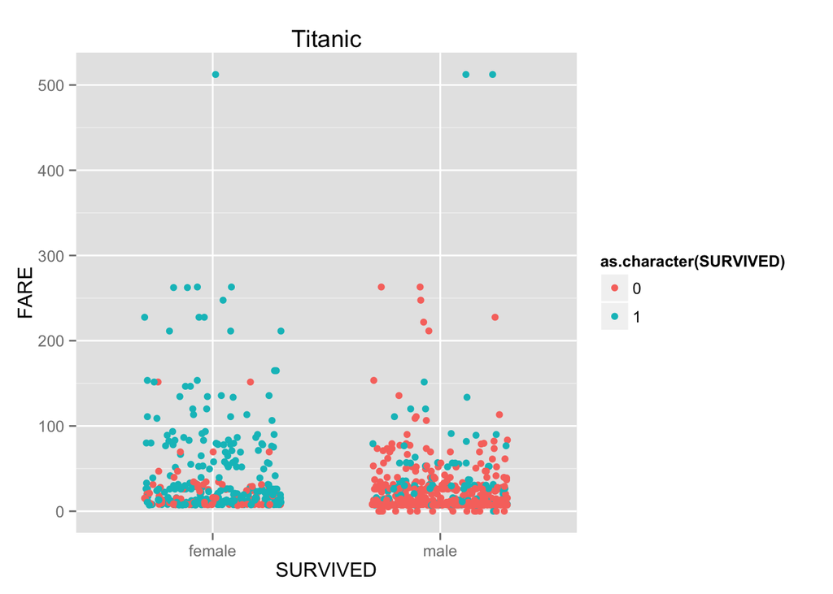

```r
source("../02 Visualizations/plot3.R", echo = TRUE)
```

**Code Analysis**

Survival is identified as a discrete variable. The legend differentiates survival; a 1 indicates survival and a 0 indicates death.

**Plot Analysis**

This visualization shows that many more females survived the Titanic crash than males. This could have been because the people on the ship wanted to get women and children off of the boat before the men. Additionally, we see that the three people that paid over $500 for their Titanic tickets all survived. No females that paid more than $200 died as a result of the Titanic crash.

### Plot #4:

This visualization uses the same dataframe as plot #2 and #3. The plot visualizes survival by sex divided by class

```
##
## > require("jsonlite")
##
## > require("RCurl")
##
## > sexNotNullDf <- data.frame(fromJSON(getURL(URLencode("129.152.144.84:5001/rest/native/?query=\"select * from titanic where sex is not null\""),
## +   .... [TRUNCATED]
##
## > ggplot() + coord_cartesian() + scale_x_discrete() +
## +     scale_y_continuous() + facet_grid(. ~ SURVIVED, labeller = label_both) +
## +     facet_gri .... [TRUNCATED]
```

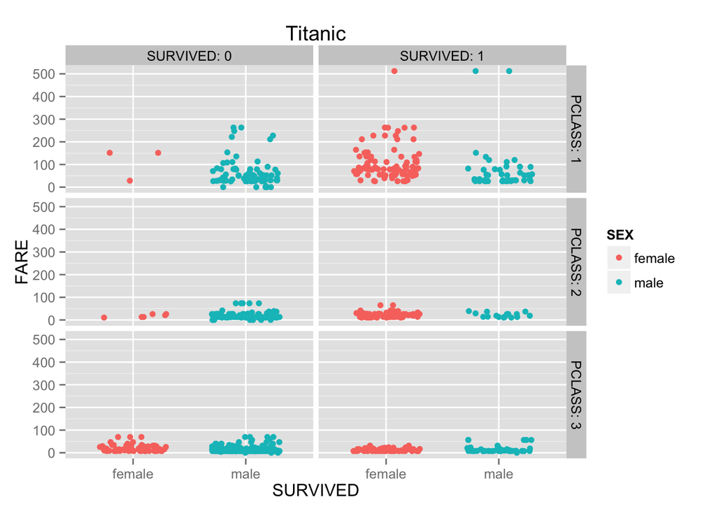

```r
source("../02 Visualizations/plot4.R", echo = TRUE)
```

**Code Analysis**

**Plot Analysis**

This visualization adds the new dimension of class. It shows an interesting correlation between how much some paid to ride and what class they were put in. There were some men who paid nothing and were in first class who did not survive. It may be that they were captain and crew since the captain should always go down with his ship. It also shows that anyone who rode for free did not survive and that there were several who paid more to ride 3rd class than those who rode 1st class.

### Plot #5:

This visualization uses a dataframe of those who rode that were no more than 10 years old. The plot visualizes survival by sex divided by class

```
##
## > require("jsonlite")
##
## > require("RCurl")
##
## > age10Df <- data.frame(fromJSON(getURL(URLencode("129.152.144.84:5001/rest/native/?query=\"select * from titanic where sex is not null and age <= 10\ .... [TRUNCATED]
##
## > ggplot() + coord_cartesian() + scale_x_discrete() +
## +     scale_y_continuous() + facet_grid(. ~ SURVIVED, labeller = label_both) +
## +     facet_gri .... [TRUNCATED]
```

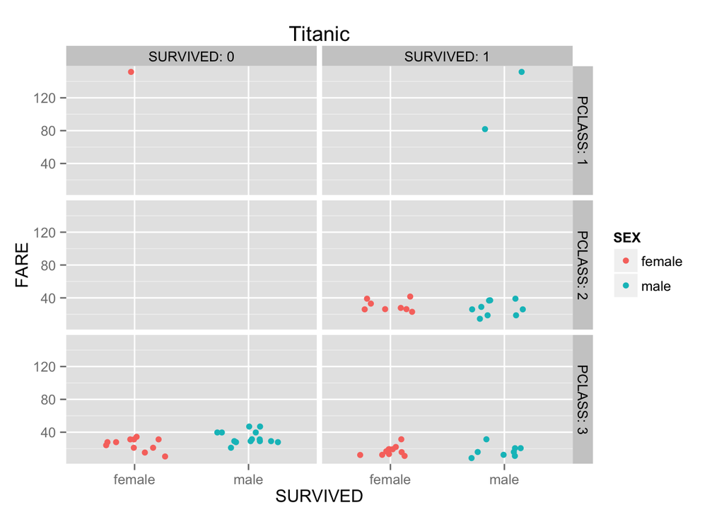

```r
source("../02 Visualizations/plot5.R", echo = TRUE)
```

**Code Analysis**

**Plot Analysis**

This shows a sad piece of data. It shows those who died or survived under the age of 10. It is interesting how much more expensive first class kids were to ride, nearly double that of any child in 2nd or 3rd class. There were less kids in first class but all male kids in first class survive, demostrating the importance of family lines for the rich.

### Plot #6:

This visualization uses the same dataframe as plot #3. The plot visualizes survival by sex divided by class but with age on the vertical axis instead of fare.

```
##
## > require("jsonlite")
##
## > require("RCurl")
##
## > ageDf <- data.frame(fromJSON(getURL(URLencode("129.152.144.84:5001/rest/native/?query=\"select * from titanic where sex is not null\""),
## +     http .... [TRUNCATED]
##
## > summary(ageDf)
##   PASSENGERID       SURVIVED          PCLASS
##  Min.   :  1.0   Min.   :0.0000   Min.   :1.000
##  1st Qu.:223.5   1st Qu.:0.0000   1st Qu.:2.000
##  Median :446.0   Median :0.0000   Median :3.000
##  Mean   :446.0   Mean   :0.3838   Mean   :2.309
##  3rd Qu.:668.5   3rd Qu.:1.0000   3rd Qu.:3.000
##  Max.   :891.0   Max.   :1.0000   Max.   :3.000
##
##                                     NAME         SEX           AGE
##  Abbing, Mr. Anthony                  :  1   female:314   null   :177
##  Abbott, Mr. Rossmore Edward          :  1   male  :577   24     : 30
##  Abbott, Mrs. Stanton (Rosa Hunt)     :  1                22     : 27
##  Abelson, Mr. Samuel                  :  1                18     : 26
##  Abelson, Mrs. Samuel (Hannah Wizosky):  1                19     : 25
##  Adahl, Mr. Mauritz Nils Martin       :  1                28     : 25
##  (Other)                              :885                (Other):581
##      SIBSP           PARCH             TICKET         FARE
##  Min.   :0.000   Min.   :0.0000   1601    :  7   Min.   :  0.00
##  1st Qu.:0.000   1st Qu.:0.0000   347082  :  7   1st Qu.:  7.91
##  Median :0.000   Median :0.0000   CA. 2343:  7   Median : 14.45
##  Mean   :0.523   Mean   :0.3816   3101295 :  6   Mean   : 32.20
##  3rd Qu.:1.000   3rd Qu.:0.0000   347088  :  6   3rd Qu.: 31.00
##  Max.   :8.000   Max.   :6.0000   CA 2144 :  6   Max.   :512.33
##                                   (Other) :852
##          CABIN     EMBARKED
##  null       :687   C   :168
##  B96 B98    :  4   null:  2
##  C23 C25 C27:  4   Q   : 77
##  G6         :  4   S   :644
##  C22 C26    :  3
##  D          :  3
##  (Other)    :186
##
## > head(ageDf)
##   PASSENGERID SURVIVED PCLASS                                  NAME    SEX
## 1         311        1      1        Hays, Miss. Margaret Bechstein female
## 2         312        1      1            Ryerson, Miss. Emily Borie female
## 3         313        0      2 Lahtinen, Mrs. William (Anna Sylfven) female
## 4         314        0      3                Hendekovic, Mr. Ignjac   male
## 5         315        0      2                    Hart, Mr. Benjamin   male
## 6         316        1      3       Nilsson, Miss. Helmina Josefina female
##   AGE SIBSP PARCH       TICKET     FARE           CABIN EMBARKED
## 1  24     0     0        11767  83.1583             C54        C
## 2  18     2     2     PC 17608 262.3750 B57 B59 B63 B66        C
## 3  26     1     1       250651  26.0000            null        S
## 4  28     0     0       349243   7.8958            null        S
## 5  43     1     1 F.C.C. 13529  26.2500            null        S
## 6  26     0     0       347470   7.8542            null        S
##
## > ggplot() + coord_cartesian() + scale_x_discrete() +
## +     scale_y_continuous() + facet_grid(PCLASS ~ SURVIVED, labeller = label_both) +
## +     labs .... [TRUNCATED]
```

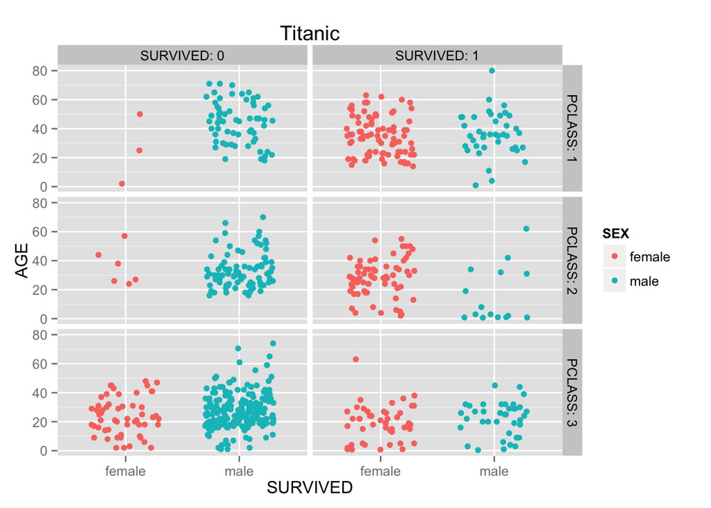

```r
source("../02 Visualizations/plot6.R", echo = TRUE)
```

**Code Analysis**

**Plot Analysis**

This visualization not only shows who survived by age but also who rode. There is a large number of 20 something males in 3rd class probably for below deck work, most of which did not survive. It also shows how childeren in 2nd class mostly survived while plenty in 3rd class did not. It also shows that the eldest passengers were in first class.